# Project Title: Personal Bank Loan Modelling

## YHills Internship Project

</center> **By:** Aashish Bansal  
**Email:** aashish22bansal@gmail.com  
The dataset contains data on 5000 customers  
The aim is to construct a model that can identify potential customers who have a higher probability of purchasing loan. Output column is </b>Personal Loan</b>.

# 1. Connecting to Google Drive

Import the datasets and libraries, check datatype, statistical summary, shape, null values etc

```python
from google.colab import drive
drive.mount('/content/drive')
```

# 2. Importing the required Libraries

```python
#Importing libraries
from matplotlib import pyplot as plt
import pandas as pd
import seaborn as sns
import numpy as np
%matplotlib inline
import warnings
warnings.filterwarnings('ignore')
```

# 3. Importing Dataset

I have use Bank Loan Modeling dataset.

Dataset is a csv file.

Pandas **read_csv** function is used to read Data sheet.

```python
#Importing the dataset
df = pd.read_csv("/content/drive/MyDrive/Project - YHills - Personal Loan Modelling/dataset/Bank_Personal_Loan_Modelling.csv")
```

## 4.2 Dataset Description

There are **12** features.  
Features are detailed below:

| Feature | Description |
| --- | --- |
| **Age** | Customer's age |
| **Experience** | Number of years of professional experience |
| **Income** | Annual income of the customer |
| **ZIPCode** | Home Address ZIP code |
| **Family** | Family size of the customer |
| **CCAvg** | Average spending on credit cards per month |
| **Education** | Education Level: 1: Undergrad 2: Graduate 3: Advanced/Professional |
| **Mortgage** | Value of house mortgage (if any) |
| **Securities Account** | Does the customer have a securities account with the bank? |
| **CD Account** | Does the customer have a certificate of deposit (CD) account with the bank? |
| **Online** | Does the customer use internet banking facilities? |
| **CreditCard** | Does the customer uses a credit card issued by UniversalBank? |
| **Personal Loan** | Did this customer accept the personal loan offered in the last campaign? |

# 4. Basic Data Analysis

## 4.1 Checking some rows in the dataset

```python
#To display top 5 rows
df.head()
```

|  | ID | Age | Experience | Income | ZIP Code | Family | CCAvg | Education | Mortgage | Personal Loan | Securities Account | CD Account | Online | CreditCard |
| --- | --- | --- | --- | --- | --- | --- | --- | --- | --- | --- | --- | --- | --- | --- |
| 0 | 1 | 25 | 1 | 49 | 91107 | 4 | 1.6 | 1 | 0 | 0 | 1 | 0 | 0 | 0 |
| 1 | 2 | 45 | 19 | 34 | 90089 | 3 | 1.5 | 1 | 0 | 0 | 1 | 0 | 0 | 0 |
| 2 | 3 | 39 | 15 | 11 | 94720 | 1 | 1.0 | 1 | 0 | 0 | 0 | 0 | 0 | 0 |
| 3 | 4 | 35 | 9 | 100 | 94112 | 1 | 2.7 | 2 | 0 | 0 | 0 | 0 | 0 | 0 |
| 4 | 5 | 35 | 8 | 45 | 91330 | 4 | 1.0 | 2 | 0 | 0 | 0 | 0 | 0 | 1 |

```python
#To display bottom 5 rows
df.tail()
```

|  | ID | Age | Experience | Income | ZIP Code | Family | CCAvg | Education | Mortgage | Personal Loan | Securities Account | CD Account | Online | CreditCard |
| --- | --- | --- | --- | --- | --- | --- | --- | --- | --- | --- | --- | --- | --- | --- |
| 4995 | 4996 | 29 | 3 | 40 | 92697 | 1 | 1.9 | 3 | 0 | 0 | 0 | 0 | 1 | 0 |
| 4996 | 4997 | 30 | 4 | 15 | 92037 | 4 | 0.4 | 1 | 85 | 0 | 0 | 0 | 1 | 0 |
| 4997 | 4998 | 63 | 39 | 24 | 93023 | 2 | 0.3 | 3 | 0 | 0 | 0 | 0 | 0 | 0 |
| 4998 | 4999 | 65 | 40 | 49 | 90034 | 3 | 0.5 | 2 | 0 | 0 | 0 | 0 | 1 | 0 |
| 4999 | 5000 | 28 | 4 | 83 | 92612 | 3 | 0.8 | 1 | 0 | 0 | 0 | 0 | 1 | 1 |

## 4.2 Checking the highest and lowest values

```python
df.head(10).style.background_gradient(cmap="PuBuGn")
```

|  | ID | Age | Experience | Income | ZIP Code | Family | CCAvg | Education | Mortgage | Personal Loan | Securities Account | CD Account | Online | CreditCard |
| --- | --- | --- | --- | --- | --- | --- | --- | --- | --- | --- | --- | --- | --- | --- |
| 0 | 1 | 25 | 1 | 49 | 91107 | 4 | 1.600000 | 1 | 0 | 0 | 1 | 0 | 0 | 0 |
| 1 | 2 | 45 | 19 | 34 | 90089 | 3 | 1.500000 | 1 | 0 | 0 | 1 | 0 | 0 | 0 |
| 2 | 3 | 39 | 15 | 11 | 94720 | 1 | 1.000000 | 1 | 0 | 0 | 0 | 0 | 0 | 0 |
| 3 | 4 | 35 | 9 | 100 | 94112 | 1 | 2.700000 | 2 | 0 | 0 | 0 | 0 | 0 | 0 |
| 4 | 5 | 35 | 8 | 45 | 91330 | 4 | 1.000000 | 2 | 0 | 0 | 0 | 0 | 0 | 1 |
| 5 | 6 | 37 | 13 | 29 | 92121 | 4 | 0.400000 | 2 | 155 | 0 | 0 | 0 | 1 | 0 |
| 6 | 7 | 53 | 27 | 72 | 91711 | 2 | 1.500000 | 2 | 0 | 0 | 0 | 0 | 1 | 0 |
| 7 | 8 | 50 | 24 | 22 | 93943 | 1 | 0.300000 | 3 | 0 | 0 | 0 | 0 | 0 | 1 |
| 8 | 9 | 35 | 10 | 81 | 90089 | 3 | 0.600000 | 2 | 104 | 0 | 0 | 0 | 1 | 0 |
| 9 | 10 | 34 | 9 | 180 | 93023 | 1 | 8.900000 | 3 | 0 | 1 | 0 | 0 | 0 | 0 |

## 4.3 Check the types of the Data

```python
# To find the dtypes in the DataFrame of each columns
df.dtypes
```

```
ID                      int64
Age                     int64
Experience              int64
Income                  int64
ZIP Code                int64
Family                  int64
CCAvg                 float64
Education               int64
Mortgage                int64
Personal Loan           int64
Securities Account      int64
CD Account              int64
Online                  int64
CreditCard              int64
dtype: object
```

# 5. Statistical Analysis

## 5.1 Viewing some basic Statistical details

```python
df.describe()
```

|  | ID | Age | Experience | Income | ZIP Code | Family | CCAvg | Education | Mortgage | Personal Loan | Securities Account | CD Account | Online | CreditCard |
| --- | --- | --- | --- | --- | --- | --- | --- | --- | --- | --- | --- | --- | --- | --- |
| count | 5000.000000 | 5000.000000 | 5000.000000 | 5000.000000 | 5000.000000 | 5000.000000 | 5000.000000 | 5000.000000 | 5000.000000 | 5000.000000 | 5000.000000 | 5000.00000 | 5000.000000 | 5000.000000 |
| mean | 2500.500000 | 45.338400 | 20.104600 | 73.774200 | 93152.503000 | 2.396400 | 1.937938 | 1.881000 | 56.498800 | 0.096000 | 0.104400 | 0.06040 | 0.596800 | 0.294000 |
| std | 1443.520003 | 11.463166 | 11.467954 | 46.033729 | 2121.852197 | 1.147663 | 1.747659 | 0.839869 | 101.713802 | 0.294621 | 0.305809 | 0.23825 | 0.490589 | 0.455637 |
| min | 1.000000 | 23.000000 | -3.000000 | 8.000000 | 9307.000000 | 1.000000 | 0.000000 | 1.000000 | 0.000000 | 0.000000 | 0.000000 | 0.00000 | 0.000000 | 0.000000 |
| 25% | 1250.750000 | 35.000000 | 10.000000 | 39.000000 | 91911.000000 | 1.000000 | 0.700000 | 1.000000 | 0.000000 | 0.000000 | 0.000000 | 0.00000 | 0.000000 | 0.000000 |
| 50% | 2500.500000 | 45.000000 | 20.000000 | 64.000000 | 93437.000000 | 2.000000 | 1.500000 | 2.000000 | 0.000000 | 0.000000 | 0.000000 | 0.00000 | 1.000000 | 0.000000 |
| 75% | 3750.250000 | 55.000000 | 30.000000 | 98.000000 | 94608.000000 | 3.000000 | 2.500000 | 3.000000 | 101.000000 | 0.000000 | 0.000000 | 0.00000 | 1.000000 | 1.000000 |
| max | 5000.000000 | 67.000000 | 43.000000 | 224.000000 | 96651.000000 | 4.000000 | 10.000000 | 3.000000 | 635.000000 | 1.000000 | 1.000000 | 1.00000 | 1.000000 | 1.000000 |

```python
# Transpose of df.describe()
df.describe().T
```

|  | count | mean | std | min | 25% | 50% | 75% | max |
| --- | --- | --- | --- | --- | --- | --- | --- | --- |
| ID | 5000.0 | 2500.500000 | 1443.520003 | 1.0 | 1250.75 | 2500.5 | 3750.25 | 5000.0 |
| Age | 5000.0 | 45.338400 | 11.463166 | 23.0 | 35.00 | 45.0 | 55.00 | 67.0 |
| Experience | 5000.0 | 20.104600 | 11.467954 | -3.0 | 10.00 | 20.0 | 30.00 | 43.0 |
| Income | 5000.0 | 73.774200 | 46.033729 | 8.0 | 39.00 | 64.0 | 98.00 | 224.0 |
| ZIP Code | 5000.0 | 93152.503000 | 2121.852197 | 9307.0 | 91911.00 | 93437.0 | 94608.00 | 96651.0 |
| Family | 5000.0 | 2.396400 | 1.147663 | 1.0 | 1.00 | 2.0 | 3.00 | 4.0 |
| CCAvg | 5000.0 | 1.937938 | 1.747659 | 0.0 | 0.70 | 1.5 | 2.50 | 10.0 |
| Education | 5000.0 | 1.881000 | 0.839869 | 1.0 | 1.00 | 2.0 | 3.00 | 3.0 |
| Mortgage | 5000.0 | 56.498800 | 101.713802 | 0.0 | 0.00 | 0.0 | 101.00 | 635.0 |
| Personal Loan | 5000.0 | 0.096000 | 0.294621 | 0.0 | 0.00 | 0.0 | 0.00 | 1.0 |
| Securities Account | 5000.0 | 0.104400 | 0.305809 | 0.0 | 0.00 | 0.0 | 0.00 | 1.0 |
| CD Account | 5000.0 | 0.060400 | 0.238250 | 0.0 | 0.00 | 0.0 | 0.00 | 1.0 |
| Online | 5000.0 | 0.596800 | 0.490589 | 0.0 | 0.00 | 1.0 | 1.00 | 1.0 |
| CreditCard | 5000.0 | 0.294000 | 0.455637 | 0.0 | 0.00 | 0.0 | 1.00 | 1.0 |

We can observe that Experience has some negative values

## 5.2 Checking the shape of DataFrame

```python
# To check the Dimensionality of the DataFrame
df.shape
```

```
(5000, 14)
```

## 5.3 Checking for Null values

```python
# To check the total null values
df.isnull().sum()
```

```
ID                    0
Age                   0
Experience            0
Income                0
ZIP Code              0
Family                0
CCAvg                 0
Education             0
Mortgage              0
Personal Loan         0
Securities Account    0
CD Account            0
Online                0
CreditCard            0
dtype: int64
```

# 6. Exploratory Data Analysis

## 6.1 Checking the number of Unique Elements in each columns

```python
df.nunique()
```

```
ID                    5000
Age                     45
Experience              47
Income                 162
ZIP Code               467
Family                   4
CCAvg                  108
Education                3
Mortgage               347
Personal Loan            2
Securities Account       2
CD Account               2
Online                   2
CreditCard               2
dtype: int64
```

```python
#Drop the Zip Code Column
df.drop(['ZIP Code'], axis = 1)
```

|  | ID | Age | Experience | Income | Family | CCAvg | Education | Mortgage | Personal Loan | Securities Account | CD Account | Online | CreditCard |
| --- | --- | --- | --- | --- | --- | --- | --- | --- | --- | --- | --- | --- | --- |
| 0 | 1 | 25 | 1 | 49 | 4 | 1.6 | 1 | 0 | 0 | 1 | 0 | 0 | 0 |
| 1 | 2 | 45 | 19 | 34 | 3 | 1.5 | 1 | 0 | 0 | 1 | 0 | 0 | 0 |
| 2 | 3 | 39 | 15 | 11 | 1 | 1.0 | 1 | 0 | 0 | 0 | 0 | 0 | 0 |
| 3 | 4 | 35 | 9 | 100 | 1 | 2.7 | 2 | 0 | 0 | 0 | 0 | 0 | 0 |
| 4 | 5 | 35 | 8 | 45 | 4 | 1.0 | 2 | 0 | 0 | 0 | 0 | 0 | 1 |
| ... | ... | ... | ... | ... | ... | ... | ... | ... | ... | ... | ... | ... | ... |
| 4995 | 4996 | 29 | 3 | 40 | 1 | 1.9 | 3 | 0 | 0 | 0 | 0 | 1 | 0 |
| 4996 | 4997 | 30 | 4 | 15 | 4 | 0.4 | 1 | 85 | 0 | 0 | 0 | 1 | 0 |
| 4997 | 4998 | 63 | 39 | 24 | 2 | 0.3 | 3 | 0 | 0 | 0 | 0 | 0 | 0 |
| 4998 | 4999 | 65 | 40 | 49 | 3 | 0.5 | 2 | 0 | 0 | 0 | 0 | 1 | 0 |
| 4999 | 5000 | 28 | 4 | 83 | 3 | 0.8 | 1 | 0 | 0 | 0 | 0 | 1 | 1 |

5000 rows × 13 columns

## 6.2 Checking Specific Details

### 6.2.1 Checking the Number of people with zero mortgage

```python
df[df['Mortgage'] == 0]['Mortgage'].value_counts()
```

```
0    3462
Name: Mortgage, dtype: int64
```

### 6.2.2 Checking the Number of people with zero Credit Card spending per month

```python
df[df['CCAvg'] == 0]['CCAvg'].value_counts()
```

```
0.0    106
Name: CCAvg, dtype: int64
```

### 6.2.3 Obtaining Value counts of Family column

```python
df['Family'].value_counts()
```

```
1    1472
2    1296
4    1222
3    1010
Name: Family, dtype: int64
```

### 6.2.4 Obtaining Value counts of Securities Account column

```python
df['Securities Account'].value_counts()
```

```
0    4478
1     522
Name: Securities Account, dtype: int64
```

### 6.2.5 Obtaining Value counts of CD Account column

```python
df['CD Account'].value_counts()
```

```
0    4698
1     302
Name: CD Account, dtype: int64
```

### 6.2.6 Obtaining Value counts of Credit Card column

```python
df['CreditCard'].value_counts()
```

```
0    3530
1    1470
Name: CreditCard, dtype: int64
```

### 6.2.7 Obtaining Value counts of Education column

```python
df['Education'].value_counts()
```

```
1    2096
3    1501
2    1403
Name: Education, dtype: int64
```

### 6.2.8 Obtaining Value counts of Online column

```python
#
df['Online'].value_counts()
```

```
1    2984
0    2016
Name: Online, dtype: int64
```

## 6.3 Plotting different Attributes

### 6.3.1 Counting the Age Attribute

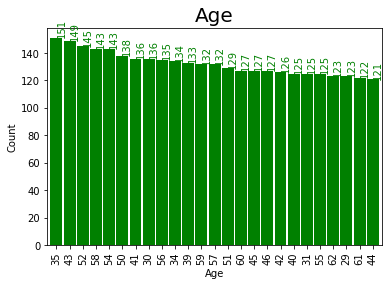

```python
age = df['Age'].value_counts().head(25)
ax = age.plot.bar(width=.9,color="Green")
plt.title("Age",size=20)
plt.xlabel("Age")
plt.ylabel("Count")
for i, v in age.reset_index().iterrows():
    ax.text(i, v.Age + 1.5, v.Age, color='green',rotation=90)
```

### 6.3.2 Checking the Experience Attribute

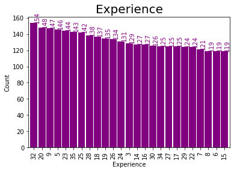

```python
experience = df['Experience'].value_counts().head(25)
ax = experience.plot.bar(width=.9,color="Purple")
plt.title("Experience",size=20)
plt.xlabel("Experience")
plt.ylabel("Count")
for i, v in experience.reset_index().iterrows():
    ax.text(i, v.Experience + 1.5, v.Experience, color='Purple',rotation=90)
```

### 6.3.3 Checking the Income Attribute

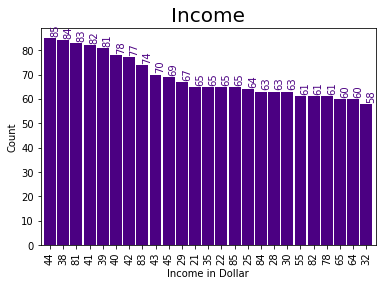

```python
Income = df['Income'].value_counts().head(25)
ax = Income.plot.bar(width=.9,color="Indigo")
plt.title("Income",size=20)
plt.xlabel("Income in Dollar")
plt.ylabel("Count")
for i, v in Income.reset_index().iterrows():
    ax.text(i, v.Income + 1.5, v.Income, color='Indigo',rotation=90)
```

### 6.3.4 Checking the permitted Loans based on Income

```python
maxIncome = df.loc[(df['Personal Loan']==1),'Income'].max()
minIncome = df.loc[(df['Personal Loan']==1),'Income'].min()
print(maxIncome)
print(minIncome)
```

```
203
60
```

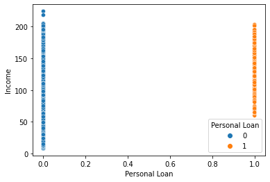

```python
sns.scatterplot(x="Personal Loan", y="Income", data=df, hue="Personal Loan")
```

### 6.3.5 Comparing Experience with respect to Age Attribute

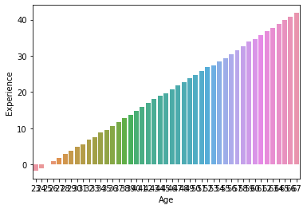

```python
sns.barplot(x="Age", y="Experience", data=df, ci=None)
```

### 6.3.6 Comparing Income with respect to Experience

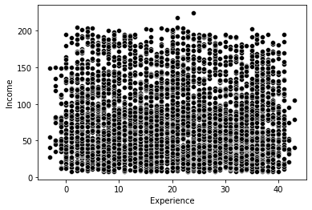

```python
sns.scatterplot(x="Experience", y="Income", data=df, color='black')
```

### 6.3.7 Comparing Martgage with respect to Income

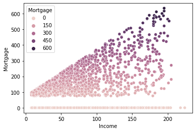

```python
sns.scatterplot(x="Income", y="Mortgage", hue="Mortgage", data=df)
```

### 6.3.8 Comparing Mortgage with respect to Personal Loan

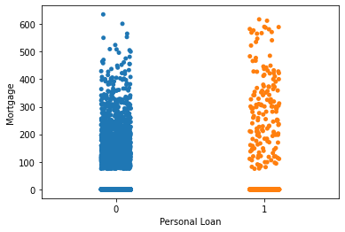

```python
sns.stripplot(y="Mortgage", x="Personal Loan", data=df)
```

### 6.3.9 Comparing Mortage with respect to Education

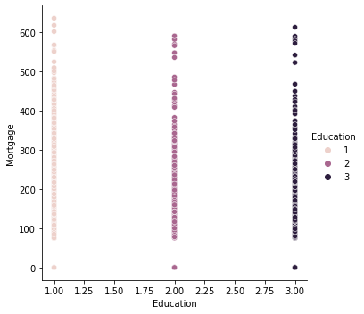

```python
sns.relplot(x="Education", y="Mortgage", data=df, hue="Education")
```

### 6.3.10 Comparing Family Size with respect to Mortgage

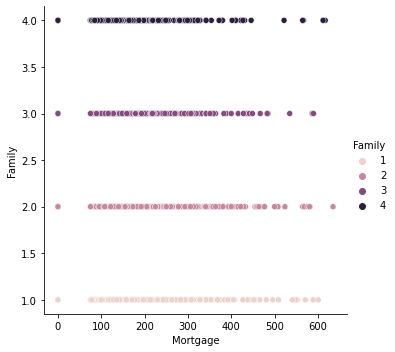

```python
sns. relplot(x="Mortgage", y="Family", data=df, hue="Family")
```

### 6.3.11 Checking the granted loans with respect to Family

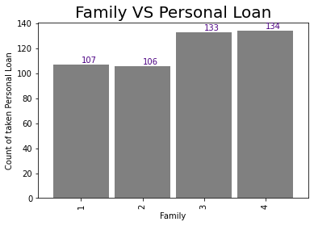

```python
family = df.Family[df['Personal Loan']==1].value_counts().sort_index()
#ax=plot(kind='bar',alpha=0.5,color="Orange")
ax = family.plot.bar(width=.9,color="Gray")
plt.title("Family VS Personal Loan",size=20)
plt.xlabel("Family")
plt.ylabel("Count of taken Personal Loan")
for i, v in family.reset_index().iterrows():
    ax.text(i, v.Family + 1.5, v.Family, color='Indigo')
```

# 7. Data Cleaning

## 7.1 Checking if any Column has Null Values

```python
df.isnull().sum()
```

```
ID                    0
Age                   0
Experience            0
Income                0
ZIP Code              0
Family                0
CCAvg                 0
Education             0
Mortgage              0
Personal Loan         0
Securities Account    0
CD Account            0
Online                0
CreditCard            0
dtype: int64
```

## 7.2 Checking if any Column has Negative values

```python
df.lt(0).any()
```

```
ID                    False
Age                   False
Experience             True
Income                False
ZIP Code              False
Family                False
CCAvg                 False
Education             False
Mortgage              False
Personal Loan         False
Securities Account    False
CD Account            False
Online                False
CreditCard            False
dtype: bool
```

## 7.3 Dropping Irrelavant column

The variable ID does not add any interesting information. There is no association between a person's customer ID and loan, also it does not provide any general conclusion for future potential loan customers. We can neglect this information for our model prediction.

```python
# To check the counts of negative values in experience column
df[df['Experience'] < 0]['Experience'].count()
```

```
52
```

```python
#To check the ammount of negative values
df[df['Experience'] < 0]['Experience'].value_counts()
```

```
-1    33
-2    15
-3     4
Name: Experience, dtype: int64
```

Since Experience Column and Age are highly correlated. Drop Experience Column

```python
# Dropping the ID and Experience column
df.drop(['ID','Experience'],axis=1,inplace=True)
```

```python
#To display top 5 rows
df.head()
```

|  | Age | Income | ZIP Code | Family | CCAvg | Education | Mortgage | Personal Loan | Securities Account | CD Account | Online | CreditCard |
| --- | --- | --- | --- | --- | --- | --- | --- | --- | --- | --- | --- | --- |
| 0 | 25 | 49 | 91107 | 4 | 1.6 | 1 | 0 | 0 | 1 | 0 | 0 | 0 |
| 1 | 45 | 34 | 90089 | 3 | 1.5 | 1 | 0 | 0 | 1 | 0 | 0 | 0 |
| 2 | 39 | 11 | 94720 | 1 | 1.0 | 1 | 0 | 0 | 0 | 0 | 0 | 0 |
| 3 | 35 | 100 | 94112 | 1 | 2.7 | 2 | 0 | 0 | 0 | 0 | 0 | 0 |
| 4 | 35 | 45 | 91330 | 4 | 1.0 | 2 | 0 | 0 | 0 | 0 | 0 | 1 |

```python
#To display bottom 5 rows
df.tail()
```

|  | Age | Income | ZIP Code | Family | CCAvg | Education | Mortgage | Personal Loan | Securities Account | CD Account | Online | CreditCard |
| --- | --- | --- | --- | --- | --- | --- | --- | --- | --- | --- | --- | --- |
| 4995 | 29 | 40 | 92697 | 1 | 1.9 | 3 | 0 | 0 | 0 | 0 | 1 | 0 |
| 4996 | 30 | 15 | 92037 | 4 | 0.4 | 1 | 85 | 0 | 0 | 0 | 1 | 0 |
| 4997 | 63 | 24 | 93023 | 2 | 0.3 | 3 | 0 | 0 | 0 | 0 | 0 | 0 |
| 4998 | 65 | 49 | 90034 | 3 | 0.5 | 2 | 0 | 0 | 0 | 0 | 1 | 0 |
| 4999 | 28 | 83 | 92612 | 3 | 0.8 | 1 | 0 | 0 | 0 | 0 | 1 | 1 |

```python
#To check the names of each column
df.columns
```

```
Index(['Age', 'Income', 'ZIP Code', 'Family', 'CCAvg', 'Education', 'Mortgage',
       'Personal Loan', 'Securities Account', 'CD Account', 'Online',
       'CreditCard'],
      dtype='object')
```

# 8. Univariate Analysis

## 8.1 Checking Age Distribution

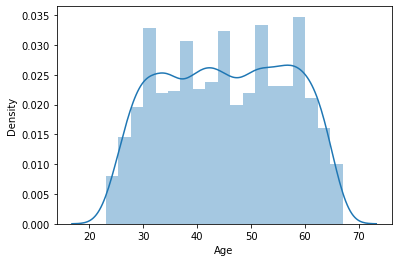

```python
sns.distplot(df["Age"])
plt.show()
```

## 8.2 Checking Income Distribution

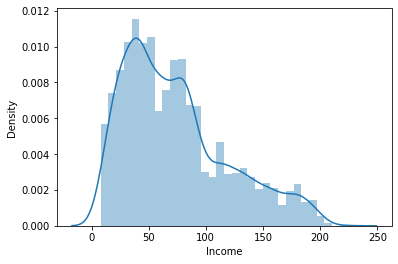

```python
sns.distplot(df["Income"])
```

## 8.3 Checking Mortgage Distribution

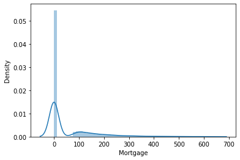

```python
sns.distplot(df["Mortgage"])
```

So, Mortgage is highly skewed.

## 8.4 Checking Credit Card Average Distribution

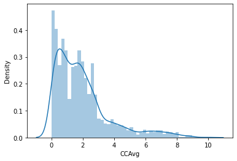

```python
sns.distplot(df["CCAvg"])
```

We have to do some feature engineering on Income, CCAVg and Mortgage variables. Because if we use skewed then it will create fault in logistic regression.

## 8.5 Checking Family Distribution

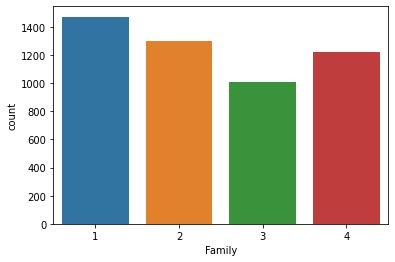

```python
# Count Plot to show Family Distributions
sns.countplot(x='Family',data=df)
```

## 8.6 Checking Education Distribution

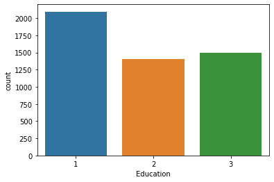

```python
# Count Plot to show Education Distributions
sns.countplot(x='Education',data=df)
```

## 8.7 Checking Credit Card Distribution

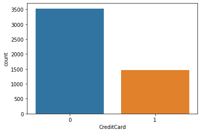

```python
# Count Plot to show Credit Card Distribution
sns.countplot(x='CreditCard',data=df)
```

## 8.8 Checking Online Distributions

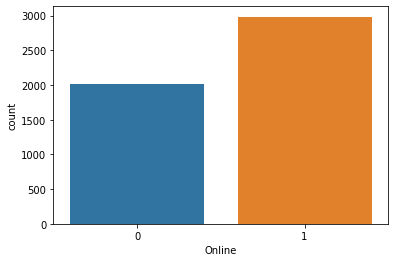

```python
#  Count Plot to show Online Distributions
sns.countplot(x='Online',data=df)
```

# 9. Multivariate Analysis

## 9.1 Checking Influence of income and education on personal loan

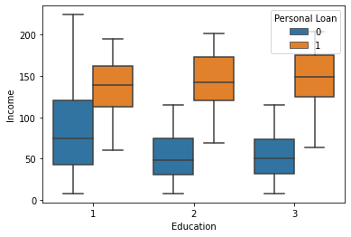

```python
sns.boxplot(x='Education',y='Income',hue='Personal Loan',data=df)
```

Observation : It seems the customers whose education level is 1 is having more income. However customers who has taken the personal loan have the same income levels

## 9.2 Obtaining the count of Securities Account

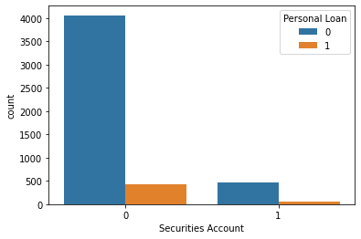

```python
sns.countplot(x="Securities Account", data=df,hue="Personal Loan")
```

## 9.3 Checking the count of Loan granted with respect to Family Size

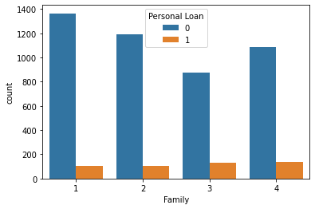

```python
sns.countplot(x='Family',data=df,hue='Personal Loan')
```

Observation: Family size does not have any impact in personal loan. But it seems families with size of 3 are more likely to take loan. When considering future campaign this might be good association.

## 9.4 Obtaining the count of CD Account

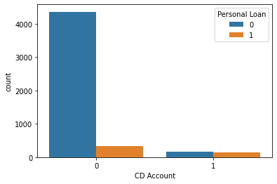

```python
sns.countplot(x='CD Account',data=df,hue='Personal Loan')
```

## 9.5 Checking Correlation between Credit Card Average and Income

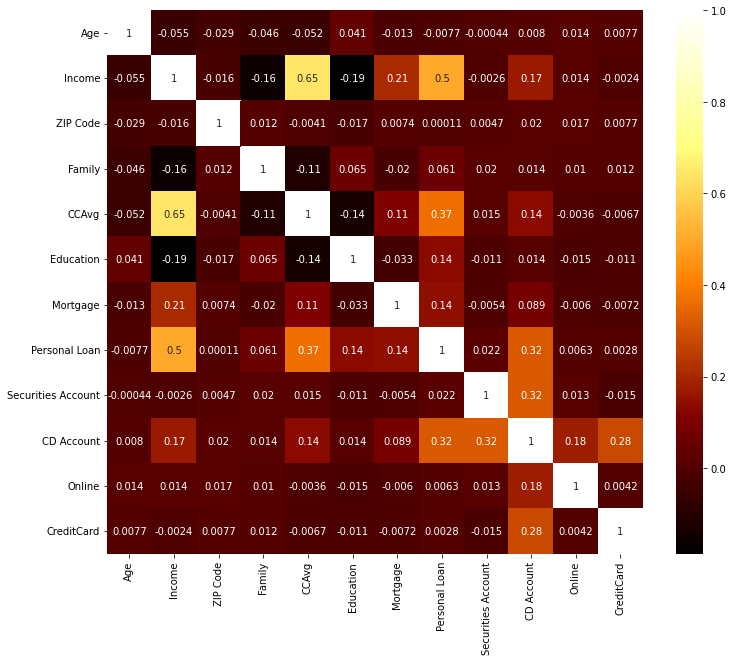

```python
# CCAvg Credit average and income are highly correlated
fig, ax = plt.subplots(figsize=(12,10))
sns.heatmap(df.corr(), cmap='afmhot' , annot = True)
```

# 10. Overall Attributes Distributions

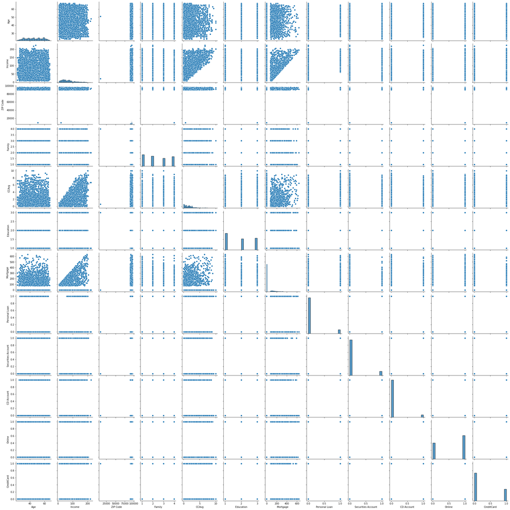

```python
sns.pairplot(df)
```

# 11. Apply necessary transformations for the feature variables

```python
data_X = df.loc[:, df.columns  != 'Personal Loan']
data_Y = df[['Personal Loan']]
```

```python
data_X
```

|  | Age | Income | ZIP Code | Family | CCAvg | Education | Mortgage | Securities Account | CD Account | Online | CreditCard |
| --- | --- | --- | --- | --- | --- | --- | --- | --- | --- | --- | --- |
| 0 | 25 | 49 | 91107 | 4 | 1.6 | 1 | 0 | 1 | 0 | 0 | 0 |
| 1 | 45 | 34 | 90089 | 3 | 1.5 | 1 | 0 | 1 | 0 | 0 | 0 |
| 2 | 39 | 11 | 94720 | 1 | 1.0 | 1 | 0 | 0 | 0 | 0 | 0 |
| 3 | 35 | 100 | 94112 | 1 | 2.7 | 2 | 0 | 0 | 0 | 0 | 0 |
| 4 | 35 | 45 | 91330 | 4 | 1.0 | 2 | 0 | 0 | 0 | 0 | 1 |
| ... | ... | ... | ... | ... | ... | ... | ... | ... | ... | ... | ... |
| 4995 | 29 | 40 | 92697 | 1 | 1.9 | 3 | 0 | 0 | 0 | 1 | 0 |
| 4996 | 30 | 15 | 92037 | 4 | 0.4 | 1 | 85 | 0 | 0 | 1 | 0 |
| 4997 | 63 | 24 | 93023 | 2 | 0.3 | 3 | 0 | 0 | 0 | 0 | 0 |
| 4998 | 65 | 49 | 90034 | 3 | 0.5 | 2 | 0 | 0 | 0 | 1 | 0 |
| 4999 | 28 | 83 | 92612 | 3 | 0.8 | 1 | 0 | 0 | 0 | 1 | 1 |

5000 rows × 11 columns

```python
data_Y
```

|  | Personal Loan |
| --- | --- |
| 0 | 0 |
| 1 | 0 |
| 2 | 0 |
| 3 | 0 |
| 4 | 0 |
| ... | ... |
| 4995 | 0 |
| 4996 | 0 |
| 4997 | 0 |
| 4998 | 0 |
| 4999 | 0 |

5000 rows × 1 columns

## 11.1 Applying the Yeo Johnson method of Transformation on the Income variable

```python
from sklearn.preprocessing import PowerTransformer
pt = PowerTransformer(method='yeo-johnson',standardize=False)
pt.fit(data_X['Income'].values.reshape(-1,1))
temp = pt.transform(data_X['Income'].values.reshape(-1,1))
data_X['Income'] = pd.Series(temp.flatten())
```

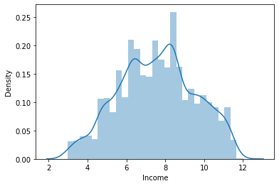

```python
# Distplot to show transformed Income variable
sns.distplot(data_X['Income'])
plt.show()
```

## 11.2 Applying the Yeo Johnson method of Transformation on the Credit Card Average variable

```python
pt = PowerTransformer(method='yeo-johnson',standardize=False)
pt.fit(data_X['CCAvg'].values.reshape(-1,1))
temp = pt.transform(data_X['CCAvg'].values.reshape(-1,1))
data_X['CCAvg'] = pd.Series(temp.flatten())
```

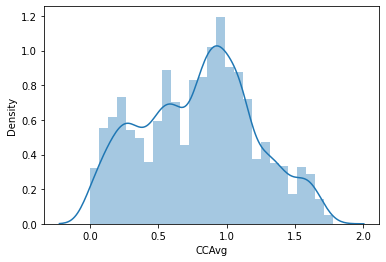

```python
# Distplot to show transformed CCAvg variable
sns.distplot(data_X['CCAvg'])
plt.show()
```

## 11.3 Binning on Mortgage variable

```python
data_X['Mortgage_Int'] = pd.cut(data_X['Mortgage'],
                               bins=[0,100,200,300,400,500,600,700],
                               labels= [0,1,2,3,4,5,6],
                               include_lowest =True)
data_X.drop('Mortgage', axis = 1, inplace= True)
```

## 11.4 Univariate Analysis

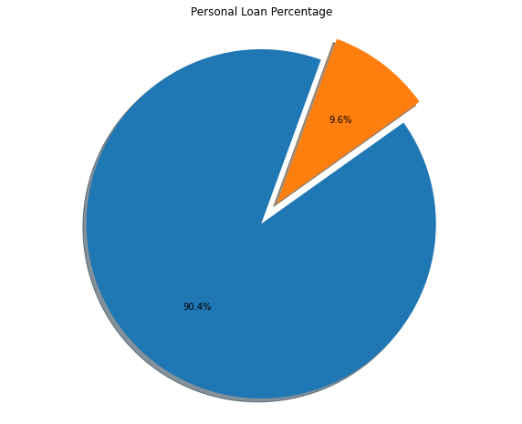

```python
## 9.6% of all the applicants get approved for personal loan
tempDF = pd.DataFrame(df['Personal Loan'].value_counts()).reset_index()
tempDF.columns = ['Labels', 'Personal Loan']
fig1, ax1 = plt.subplots(figsize=(10,8))
explode = (0, 0.15)
ax1.pie(tempDF['Personal Loan'] , explode= explode, autopct= '%1.1f%%',
       shadow=True , startangle = 70)
ax1.axis('equal')
plt.title('Personal Loan Percentage')
plt.show()
```

```python
# To display top 5 rows
data_X.head()
```

|  | Age | Income | ZIP Code | Family | CCAvg | Education | Securities Account | CD Account | Online | CreditCard | Mortgage_Int |
| --- | --- | --- | --- | --- | --- | --- | --- | --- | --- | --- | --- |
| 0 | 25 | 6.827583 | 91107 | 4 | 0.845160 | 1 | 1 | 0 | 0 | 0 | 0 |
| 1 | 45 | 5.876952 | 90089 | 3 | 0.814478 | 1 | 1 | 0 | 0 | 0 | 0 |
| 2 | 39 | 3.504287 | 94720 | 1 | 0.633777 | 1 | 0 | 0 | 0 | 0 | 0 |
| 3 | 35 | 8.983393 | 94112 | 1 | 1.107427 | 2 | 0 | 0 | 0 | 0 | 0 |
| 4 | 35 | 6.597314 | 91330 | 4 | 0.633777 | 2 | 0 | 0 | 0 | 1 | 0 |

# 12. Normalising and Splitting the dataset

```python
from sklearn.model_selection import train_test_split
```

The dataset will be split into training and testing data in the ratio of 70:30 respectively.  
We use stratify parameter of train_test_split function to get the same class distribution across train and test sets.

```python
# Splitting the data into train and test.
X_train,X_test,Y_train,Y_test = train_test_split(data_X,data_Y,test_size = 0.3, random_state = 0,stratify = data_Y)
```

```python
X_train
```

|  | Age | Income | ZIP Code | Family | CCAvg | Education | Securities Account | CD Account | Online | CreditCard | Mortgage_Int |
| --- | --- | --- | --- | --- | --- | --- | --- | --- | --- | --- | --- |
| 3789 | 51 | 5.058173 | 94301 | 3 | 0.322049 | 1 | 0 | 0 | 1 | 1 | 0 |
| 758 | 64 | 5.948841 | 90266 | 1 | 0.814478 | 2 | 1 | 0 | 0 | 0 | 0 |
| 2868 | 52 | 5.651776 | 94923 | 4 | 0.902279 | 1 | 0 | 0 | 1 | 1 | 0 |
| 2550 | 32 | 4.661500 | 93106 | 1 | 0.384645 | 3 | 0 | 0 | 1 | 0 | 1 |
| 2150 | 62 | 7.097040 | 91320 | 1 | 0.544710 | 1 | 1 | 0 | 0 | 1 | 0 |
| ... | ... | ... | ... | ... | ... | ... | ... | ... | ... | ... | ... |
| 3597 | 56 | 6.937650 | 92028 | 3 | 0.954467 | 3 | 0 | 0 | 1 | 0 | 0 |
| 4670 | 52 | 11.394571 | 94305 | 1 | 0.874387 | 1 | 0 | 0 | 1 | 0 | 0 |
| 988 | 63 | 5.728502 | 94998 | 1 | 0.928941 | 2 | 0 | 0 | 0 | 0 | 0 |
| 2037 | 35 | 6.991517 | 95616 | 2 | 0.633777 | 2 | 0 | 0 | 0 | 1 | 0 |
| 2174 | 30 | 9.691160 | 95605 | 2 | 1.179285 | 1 | 0 | 0 | 1 | 0 | 0 |

3500 rows × 11 columns

```python
X_test
```

|  | Age | Income | ZIP Code | Family | CCAvg | Education | Securities Account | CD Account | Online | CreditCard | Mortgage_Int |
| --- | --- | --- | --- | --- | --- | --- | --- | --- | --- | --- | --- |
| 9 | 34 | 11.100150 | 93023 | 1 | 1.722825 | 3 | 0 | 0 | 0 | 0 | 0 |
| 461 | 55 | 8.302424 | 92123 | 2 | 1.271937 | 1 | 1 | 0 | 0 | 0 | 0 |
| 3700 | 48 | 9.831967 | 94608 | 1 | 1.497521 | 1 | 1 | 0 | 0 | 0 | 0 |
| 1559 | 59 | 9.049404 | 92677 | 4 | 1.162177 | 2 | 0 | 0 | 1 | 0 | 1 |
| 4558 | 44 | 8.341020 | 95521 | 2 | 0.322049 | 1 | 0 | 0 | 1 | 1 | 0 |
| ... | ... | ... | ... | ... | ... | ... | ... | ... | ... | ... | ... |
| 2180 | 58 | 6.414718 | 91380 | 2 | 0.845160 | 3 | 0 | 0 | 1 | 0 | 0 |
| 3484 | 45 | 7.044639 | 92104 | 3 | 1.067713 | 2 | 0 | 0 | 0 | 0 | 1 |
| 2965 | 53 | 5.651776 | 91605 | 2 | 0.322049 | 3 | 0 | 0 | 0 | 1 | 1 |
| 2493 | 34 | 6.827583 | 94025 | 1 | 1.067713 | 3 | 0 | 0 | 0 | 0 | 0 |
| 3224 | 45 | 7.299875 | 94025 | 3 | 0.253539 | 3 | 1 | 0 | 1 | 0 | 0 |

1500 rows × 11 columns

```python
Y_train
```

|  | Personal Loan |
| --- | --- |
| 3789 | 0 |
| 758 | 0 |
| 2868 | 0 |
| 2550 | 0 |
| 2150 | 0 |
| ... | ... |
| 3597 | 0 |
| 4670 | 0 |
| 988 | 0 |
| 2037 | 0 |
| 2174 | 0 |

3500 rows × 1 columns

```python
Y_test
```

|  | Personal Loan |
| --- | --- |
| 9 | 1 |
| 461 | 0 |
| 3700 | 0 |
| 1559 | 1 |
| 4558 | 0 |
| ... | ... |
| 2180 | 0 |
| 3484 | 0 |
| 2965 | 0 |
| 2493 | 0 |
| 3224 | 0 |

1500 rows × 1 columns

```python
X_train.reset_index(drop= True, inplace= True);
X_test.reset_index(drop= True, inplace= True);
Y_train.reset_index(drop= True, inplace= True);
Y_test.reset_index(drop= True, inplace= True);
```

```python
X_train
```

|  | Age | Income | ZIP Code | Family | CCAvg | Education | Securities Account | CD Account | Online | CreditCard | Mortgage_Int |
| --- | --- | --- | --- | --- | --- | --- | --- | --- | --- | --- | --- |
| 0 | 51 | 5.058173 | 94301 | 3 | 0.322049 | 1 | 0 | 0 | 1 | 1 | 0 |
| 1 | 64 | 5.948841 | 90266 | 1 | 0.814478 | 2 | 1 | 0 | 0 | 0 | 0 |
| 2 | 52 | 5.651776 | 94923 | 4 | 0.902279 | 1 | 0 | 0 | 1 | 1 | 0 |
| 3 | 32 | 4.661500 | 93106 | 1 | 0.384645 | 3 | 0 | 0 | 1 | 0 | 1 |
| 4 | 62 | 7.097040 | 91320 | 1 | 0.544710 | 1 | 1 | 0 | 0 | 1 | 0 |
| ... | ... | ... | ... | ... | ... | ... | ... | ... | ... | ... | ... |
| 3495 | 56 | 6.937650 | 92028 | 3 | 0.954467 | 3 | 0 | 0 | 1 | 0 | 0 |
| 3496 | 52 | 11.394571 | 94305 | 1 | 0.874387 | 1 | 0 | 0 | 1 | 0 | 0 |
| 3497 | 63 | 5.728502 | 94998 | 1 | 0.928941 | 2 | 0 | 0 | 0 | 0 | 0 |
| 3498 | 35 | 6.991517 | 95616 | 2 | 0.633777 | 2 | 0 | 0 | 0 | 1 | 0 |
| 3499 | 30 | 9.691160 | 95605 | 2 | 1.179285 | 1 | 0 | 0 | 1 | 0 | 0 |

3500 rows × 11 columns

```python
X_test
```

|  | Age | Income | ZIP Code | Family | CCAvg | Education | Securities Account | CD Account | Online | CreditCard | Mortgage_Int |
| --- | --- | --- | --- | --- | --- | --- | --- | --- | --- | --- | --- |
| 0 | 34 | 11.100150 | 93023 | 1 | 1.722825 | 3 | 0 | 0 | 0 | 0 | 0 |
| 1 | 55 | 8.302424 | 92123 | 2 | 1.271937 | 1 | 1 | 0 | 0 | 0 | 0 |
| 2 | 48 | 9.831967 | 94608 | 1 | 1.497521 | 1 | 1 | 0 | 0 | 0 | 0 |
| 3 | 59 | 9.049404 | 92677 | 4 | 1.162177 | 2 | 0 | 0 | 1 | 0 | 1 |
| 4 | 44 | 8.341020 | 95521 | 2 | 0.322049 | 1 | 0 | 0 | 1 | 1 | 0 |
| ... | ... | ... | ... | ... | ... | ... | ... | ... | ... | ... | ... |
| 1495 | 58 | 6.414718 | 91380 | 2 | 0.845160 | 3 | 0 | 0 | 1 | 0 | 0 |
| 1496 | 45 | 7.044639 | 92104 | 3 | 1.067713 | 2 | 0 | 0 | 0 | 0 | 1 |
| 1497 | 53 | 5.651776 | 91605 | 2 | 0.322049 | 3 | 0 | 0 | 0 | 1 | 1 |
| 1498 | 34 | 6.827583 | 94025 | 1 | 1.067713 | 3 | 0 | 0 | 0 | 0 | 0 |
| 1499 | 45 | 7.299875 | 94025 | 3 | 0.253539 | 3 | 1 | 0 | 1 | 0 | 0 |

1500 rows × 11 columns

```python
Y_train
```

|  | Personal Loan |
| --- | --- |
| 0 | 0 |
| 1 | 0 |
| 2 | 0 |
| 3 | 0 |
| 4 | 0 |
| ... | ... |
| 3495 | 0 |
| 3496 | 0 |
| 3497 | 0 |
| 3498 | 0 |
| 3499 | 0 |

3500 rows × 1 columns

```python
Y_test
```

|  | Personal Loan |
| --- | --- |
| 0 | 1 |
| 1 | 0 |
| 2 | 0 |
| 3 | 1 |
| 4 | 0 |
| ... | ... |
| 1495 | 0 |
| 1496 | 0 |
| 1497 | 0 |
| 1498 | 0 |
| 1499 | 0 |

1500 rows × 1 columns

# 13. Standardizing the Dataset

```python
from sklearn.preprocessing import StandardScaler
```

Standardization of a dataset is a common requirement for many machine learning estimators: they might behave badly if the individual features do not more or less look like standard normally distributed data (e.g. Gaussian with 0 mean and unit variance).

We will apply the StandardScaler to the dataset to standardize the input variables

```python
for ind, column in enumerate(X_train.columns):
    scaler = StandardScaler()

    #fit to train data
    scaler.fit(X_train[[column]])

    #transform train data
    np_array = scaler.transform(X_train[[column]])
    X_train.loc[: , column] = pd.Series(np_array.flatten())

    #transform test data
    np_array = scaler.transform(X_test[[column]])
    X_test.loc[: , column] = pd.Series(np_array.flatten())
```

# 14. Logistic Regression

```python
from sklearn.linear_model import LogisticRegression
```

## 14.1 Creating the Logistic Regression Model

```python
model_LR = LogisticRegression(random_state = 0)
```

## 14.2 Training the Model

```python
model_LR.fit(X_train, Y_train)
```

```
LogisticRegression(C=1.0, class_weight=None, dual=False, fit_intercept=True,
                   intercept_scaling=1, l1_ratio=None, max_iter=100,
                   multi_class='auto', n_jobs=None, penalty='l2',
                   random_state=0, solver='lbfgs', tol=0.0001, verbose=0,
                   warm_start=False)
```

## 14.3 Evaluating the Model

```python
from sklearn.metrics import confusion_matrix, recall_score , precision_score , f1_score , accuracy_score, roc_auc_score
```

### 14.3.1 Predicting from the Model

```python
X_test_predictions_model_LR = model_LR.predict(X_test)
X_test_predictions_model_LR
```

```
array([1, 0, 0, ..., 0, 0, 0])
```

### 14.3.2 Obtaining the Accuracy of the Model on Training Data

```python
# Accuracy of train data
model_LR.score(X_train, Y_train)
```

```
0.9568571428571429
```

### 14.3.3 Obtaining the Accuracy of the Model on Testing Data

```python
# Accuracy of test data
model_LR.score(X_test,Y_test)
```

```
0.9546666666666667
```

### 14.3.4 Obtaining the Confusion Matrix

```python
# Defining the Confusion Matrix
def Confusion_Matrix(actual, predicted):
    cm = confusion_matrix(actual, predicted)
    fig, ax = plt.subplots(figsize=(8,6))
    ax.set_ylim([0,5])
    sns.heatmap(cm, annot=True, fmt= '.2f', xticklabels= [0,1], yticklabels=[0,1])
    plt.ylabel('Observed')
    plt.xlabel('Predicted')
    plt.show()
```

```python
Y_test.shape
```

```
(1500, 1)
```

```
Confusion Matrix
```

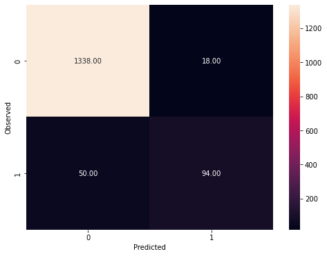

```
None
```

```python
print('Confusion Matrix')
print(Confusion_Matrix(Y_test,X_test_predictions_model_LR.reshape(-1,1)))
```

```python
from sklearn.metrics import confusion_matrix
confusion_matrix_model_LR = confusion_matrix(Y_test,X_test_predictions_model_LR.reshape(-1,1))
confusion_matrix_model_LR
```

```
array([[1338,   18],
       [  50,   94]])
```

## 14.4. Print all the metrics related for evaluating the model performance

```python
from sklearn.metrics import classification_report
print(classification_report(Y_test,X_test_predictions_model_LR))
```

```
              precision    recall  f1-score   support

           0       0.96      0.99      0.98      1356
           1       0.84      0.65      0.73       144

    accuracy                           0.95      1500
   macro avg       0.90      0.82      0.85      1500
weighted avg       0.95      0.95      0.95      1500
```

## 14.5 Obtaining the ROC-AUC Score

```python
print("Roc Auc Score: ", roc_auc_score(Y_test,X_test_predictions_model_LR))
```

```
Roc Auc Score:  0.819751720747296
```

For Logistic Regression we got 95% accuracy for test data. The F1 score is 0.73. Now lets compare that values with other models.

# 15. Random Forest Classifier

Random forest is an ensemble machine learning algorithm.

It is perhaps the most popular and widely used machine learning algorithm given its good or excellent performance across a wide range of classification and regression predictive modeling problems.

It works in four steps:

1)Select random samples from a given dataset.

2)Construct a decision tree for each sample and get a prediction result from each decision tree.

3)Perform a vote for each predicted result.

4)Select the prediction result with the most votes as the final prediction.

## 15.1 Creating the Random Forest Model

```python
from sklearn.ensemble import RandomForestClassifier
model_RF = RandomForestClassifier(n_estimators=500, max_depth=8)
```

## 15.2 Training the Model

```python
model_RF.fit(X_train, Y_train)
```

```
RandomForestClassifier(bootstrap=True, ccp_alpha=0.0, class_weight=None,
                       criterion='gini', max_depth=8, max_features='auto',
                       max_leaf_nodes=None, max_samples=None,
                       min_impurity_decrease=0.0, min_impurity_split=None,
                       min_samples_leaf=1, min_samples_split=2,
                       min_weight_fraction_leaf=0.0, n_estimators=500,
                       n_jobs=None, oob_score=False, random_state=None,
                       verbose=0, warm_start=False)
```

## 15.2 Evaluating the Model

```python
X_test_predictions_model_RF = model_RF.predict(X_test)
X_test_predictions_model_RF
```

```
array([1, 0, 0, ..., 0, 0, 0])
```

### 15.2.1 Obtaining the Accuracy of the Model on Training Data

```python
# Accuracy of train data
model_RF.score(X_train, Y_train)
```

```
0.9945714285714286
```

### 15.2.2 Obtaining the Accuracy of the Model on Testing Data

```python
# Accuracy of test data
model_RF.score(X_test,Y_test)
```

```
0.9873333333333333
```

### 15.2.3 Obtaining the Confusion Matrix

```
Confusion Matrix
```

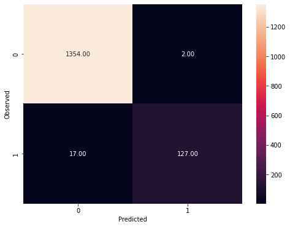

```
None
```

```python
print('Confusion Matrix')
print(Confusion_Matrix(Y_test,X_test_predictions_model_RF.reshape(-1,1)))
```

```python
from sklearn.metrics import confusion_matrix
confusion_matrix_RF = confusion_matrix(Y_test,X_test_predictions_model_RF.reshape(-1,1))
confusion_matrix_RF
```

```
array([[1354,    2],
       [  17,  127]])
```

## 15.4. Print all the metrics related for evaluating the model performance

```python
from sklearn.metrics import classification_report
print(classification_report(Y_test,X_test_predictions_model_RF))
```

```
              precision    recall  f1-score   support

           0       0.99      1.00      0.99      1356
           1       0.98      0.88      0.93       144

    accuracy                           0.99      1500
   macro avg       0.99      0.94      0.96      1500
weighted avg       0.99      0.99      0.99      1500
```

## 15.5 Obtaining the ROC AUC Score

```python
print("ROC AUC Score: ", roc_auc_score(Y_test,X_test_predictions_model_RF))
```

```
ROC AUC Score:  0.9402347590953786
```

The ROC AUC score and F1 score are higher then Logistic Regression model.

# 16. Decision Tree Classifier

Decision Trees (DTs) are a non-parametric **supervised learning** method used for classification and regression. The goal is to create a model that predicts the value of a target variable by learning simple decision rules inferred from the data features.

```python
from sklearn.tree import DecisionTreeClassifier
from sklearn.model_selection import RepeatedStratifiedKFold
```

## 16.1 Creating the Model

```python
model_DT = DecisionTreeClassifier(random_state=0, max_depth=8)
```

## 16.2 Training the Model

```python
model_DT.fit(X_train, Y_train)
```

```
DecisionTreeClassifier(ccp_alpha=0.0, class_weight=None, criterion='gini',
                       max_depth=8, max_features=None, max_leaf_nodes=None,
                       min_impurity_decrease=0.0, min_impurity_split=None,
                       min_samples_leaf=1, min_samples_split=2,
                       min_weight_fraction_leaf=0.0, presort='deprecated',
                       random_state=0, splitter='best')
```

## 16.3 Evaluating the Model

```python
X_test_predictions_model_DT = model_DT.predict(X_test)
X_test_predictions_model_DT
```

```
array([1, 0, 0, ..., 0, 0, 0])
```

### 16.3.1 Obtaining the Accuracy of the Model on Training Data

```python
# Accuracy of train data
model_DT.score(X_train, Y_train)
```

```
0.996
```

### 16.3.2 Obtaining the Accuracy of the Model on Testing Data

```python
# Accuracy of test data
model_DT.score(X_test,Y_test)
```

```
0.98
```

### 16.3.3 Obtaining the Confusion Matrix

```
Confusion Matrix
```

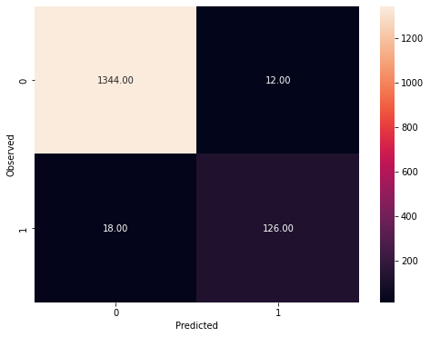

```
None
```

```python
print('Confusion Matrix')
print(Confusion_Matrix(Y_test,X_test_predictions_model_DT.reshape(-1,1)))
```

```python
from sklearn.metrics import confusion_matrix
cm = confusion_matrix(Y_test,X_test_predictions_model_DT.reshape(-1,1))
cm
```

```
array([[1344,   12],
       [  18,  126]])
```

## 16.4 Print all the metrics related for evaluating the model performance

```python
from sklearn.metrics import classification_report
print(classification_report(Y_test,X_test_predictions_model_DT))
```

```
              precision    recall  f1-score   support

           0       0.99      0.99      0.99      1356
           1       0.91      0.88      0.89       144

    accuracy                           0.98      1500
   macro avg       0.95      0.93      0.94      1500
weighted avg       0.98      0.98      0.98      1500
```

## 16.5 Obtaining the ROC-AUC Score

```python
print("Roc Auc Score: ", roc_auc_score(Y_test,X_test_predictions_model_DT))
```

```
Roc Auc Score:  0.933075221238938
```

# 17. Naive Bayes

Bayes’ Theorem provides a way that we can calculate the probability of a piece of data belonging to a given class, given our prior knowledge. Bayes’ Theorem is stated as:

P(class|data) = (P(data|class) * P(class)) / P(data)  
Where P(class|data) is the probability of class given the provided data.

## 17.1 Creating the Model

```python
from sklearn.naive_bayes import GaussianNB
model_NB = GaussianNB()
```

## 17.2 Training the Model

```python
model_NB.fit(X_train,Y_train)
```

```
GaussianNB(priors=None, var_smoothing=1e-09)
```

## 17.3 Evaluating the Model

```python
X_test_predictions_model_NB = model_NB.predict(X_test)
X_test_predictions_model_NB
```

```
array([1, 0, 0, ..., 0, 0, 0])
```

### 17.3.1 Obtaining the Accuracy of the Model on Training Data

```python
# Accuracy of train data
model_NB.score(X_train, Y_train)
```

```
0.9105714285714286
```

### 17.3.2 Obtaining the Accuracy of the Model on Testing Data

```python
# Accuracy of test data
model_NB.score(X_test,Y_test)
```

```
0.9153333333333333
```

### 17.3.3 Obtaining the Confusion Matrix

```
Confusion Matrix
```

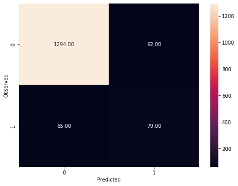

```
None
```

```python
print('Confusion Matrix')
print(Confusion_Matrix(Y_test,X_test_predictions_model_NB.reshape(-1,1)))
```

```python
from sklearn.metrics import confusion_matrix
cm = confusion_matrix(Y_test,X_test_predictions_model_NB.reshape(-1,1))
cm
```

```
array([[1294,   62],
       [  65,   79]])
```

## 17.4 Print all the metric related for evaluating the Model Performance

```python
from sklearn.metrics import classification_report
print(classification_report(Y_test,X_test_predictions_model_NB))
```

```
              precision    recall  f1-score   support

           0       0.95      0.95      0.95      1356
           1       0.56      0.55      0.55       144

    accuracy                           0.92      1500
   macro avg       0.76      0.75      0.75      1500
weighted avg       0.91      0.92      0.91      1500
```

## 17.5 Obtaining the ROC_AUC Score

```python
print("Roc Auc Score: ", roc_auc_score(Y_test,X_test_predictions_model_NB))
```

```
Roc Auc Score:  0.7514441986234022
```

# 18. Results obtained in the Model

In the first step of this project we imported various libraries and our data. Than we found out various things about our data.

After this we used several models to make predictions.

1. Logistic Regression
2. Random Forest Classifier
3. Decision Tree Classifier
4. Naive Bayes

### 1. Logistic Regression

CONFUSION MATRIX: [[1338, 18], [ 50, 94]]

CLASSIFICATION REPORT: precision recall f1-score support

```
                0       0.96      0.99      0.98      1356
                1       0.84      0.65      0.73       144

         accuracy                           0.95      1500
        macro avg       0.90      0.82      0.85      1500
     weighted avg       0.95      0.95      0.95      1500
```

### 2. Random Forest Classifier

ACCURACY SCORE: 98.73333333333333%

CONFUSION MATRIX: [[1354, 2], [ 17, 127]]

CLASSIFICATION REPORT: precision recall f1-score support

[output not shown]

### 3. Decision Tree Classifier

ACCURACY SCORE: 98%

CONFUSION MATRIX: [[1344, 12], [ 18, 126]]

CLASSIFICATION REPORT: precision recall f1-score support

```
                  0       0.99      0.99      0.99      1356
                  1       0.91      0.88      0.89       144

           accuracy                           0.98      1500
          macro avg       0.95      0.93      0.94      1500
       weighted avg       0.98      0.98      0.98      1500
```

### 4. Naive Bayes

CONFUSION MATRIX: [[1294, 62] [ 65, 79]]

CLASSIFICATION REPORT: precision recall f1-score support

```
                   0       0.95      0.95      0.95      1356
                   1       0.56      0.55      0.55       144

            accuracy                           0.92      1500
           macro avg       0.76      0.75      0.75      1500
        weighted avg       0.91      0.92      0.91      1500
```

### Conclusion

Four classification algorithms were used in this project. From the implementation, it seems like **Random Forest Classifier** have the highest accuracy and we can choose that as our final model